# Potential assessment models for North Sea Sprat

Author

Nis Sand Jacobsen and Ole Henriksen

## Introduction

This repository serves to compare different potential model configurations for the North Sea sprat. All the models we will show are based on the seasonal *smsR* model. Until 2025 the model has run with ADMB, but here we use the smsR package available at

**Note**

https://github.com/nissandjac/smsr

*smsR* is an R package which can be used to set up seasonal assessment through few R functions. Each of the functions offer simple to complex model setups, which can both respect historical assessment methods and more modern implementation of e.g., random effects. The package is currently used as assessments for the four North Sea Sandeel stocks, and a thorough comparison of the TMB and ADMB performance can be seen in the WKSANDEEL report. *smsR* provides close to identical parameter estimations as the legacy ADMB SMS code, however there might be some minute differences, in particular due to how parameters close to the boundary is treated in ADMB and TMB. Below is a figure showing the similarity of derived stock quantities from the assessment performed in 2025

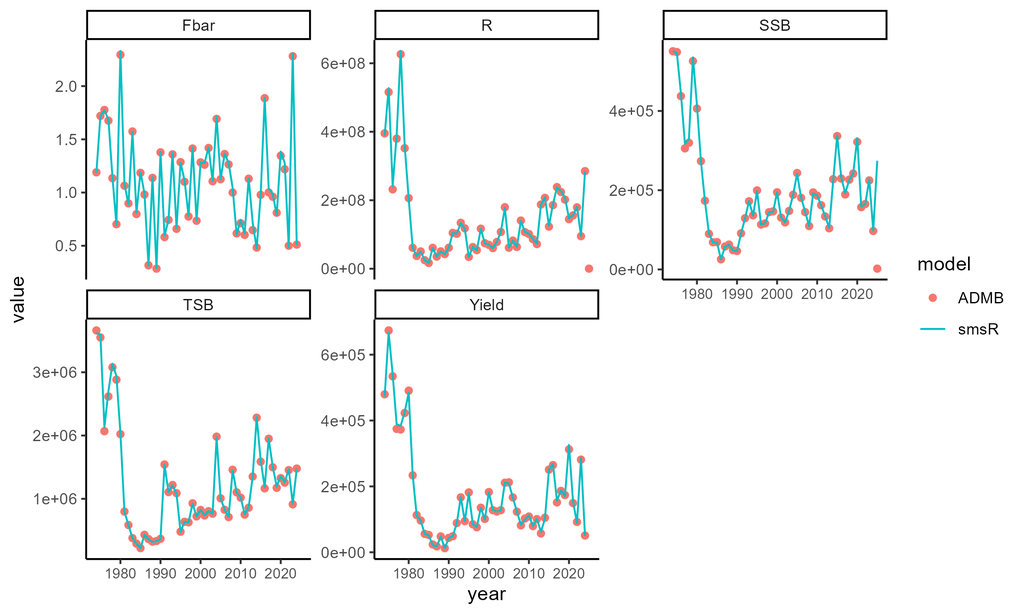

Comparison of sms in ADMB and TMB (smsR). Blue lines show smsR and red does show the output from the accepted assessment.

We have chosen model setups that are close to the previous ones, but all the models we will provide here has a transparent data flow, and try to follow best statistical practices. Over the history of the stock many small modifications have been applied to the model setup and input data to a point where some of the changes are not traceable anymore. By resetting all these changes we provide options for a model with annual, half-year, and quarterly time steps.

The current sprat model originated in the 2018 sprat benchmark. In the last couple of years there has been some issues with the model leading to ad-hoc fixes in order to get an accepted assessment. Each of these issues are described in detail below.

## Current issues with the assessment.

In the past years the model has had convergence issues, particularly with the maximum gradient being above an acceptable level. The issue has been solved by taking the 0-group from the Q1 survey and scaling it differently than the other surveys. *smsR* does not internally scale the surveys, so this method does not change that issue. The core of the issue lies elsewhere; there is large confounding between the parameter estimating survey density dependence (the so-called *power law*) and the survey catchability parameter *Q*. The survey *power law* is implemented for two reasons that are linked.

## Current model implementation

Implementation details follow SMS defaults adapted for sprat. The objective function includes catch and survey components (stock–recruit is a down-weighted hockey stick with tiny influence). Mean F is calculated over ages 1–2; selectivity is age- and season-specific. Minimum observation CVs are imposed (e.g., surveys ≥0.30) and zero catches are excluded from the likelihood. For inputs, Norwegian coastal sprat and specific 3.a rectangles are excluded; IBTS indices are built with ALKs and delta-type models (with haul-duration handled in the index calculation) and then used as input to SMS. To reduce retrospective bias from very large 0-group signals, a power function on IBTS Q1 age-0 catchability was added in the sprat implementation, to damping extreme recruitment years; this is on top of the standard survey catchability *Q*. Short-term projections use terminal stock numbers, three-year means for weights/M, constant maturity, the latest exploitation pattern, and a geometric-mean recruitment.

The survey observation function in the model is described as

$$N_{i,\mathrm{survey}} = q_i \, N_i^{p_i}$$
Where $N_{i,\mathrm{survey}}$ are the observed numbers at age in the survey, $q_i$ is the age specific catchability, $N_i$ are the numbers in the total population, and $p_i$ is the density dependent survey power law. $p_i$ and $q_i$ are both estimated parameters.

Biologically, the parameter represents that the survey is likely to observe relatively more individuals in years with high abundance.

### Residual patterns in catches

Another issue has been massive residual patterns, which has been solved by moving the catches into seasons where they did not originate. The catches from season 4 has since the benchmark been moved into season 3, except for the inital model year (as *ADMB* was then not able to converge). There is some confusion to where the catches in season 4 in the initial model year come from in the current data files, as the data has been added one year at a time.

### Parameter issues

Several of the models parameters are estimated on the boundaries, leading to slow model convergence in TMB. ADMB has a particular feature that ‘nudges’ parameters away from boundary conditions leading to the perception that a parameter has been correctly estimated, when in reality it is stuck in an infinitely small difference between the estimated parameter and the set boundary.

The parameters that are estimated poorly are related to the variance of catches in the seasons that has small total catch compared to season 1 (Figure 1).

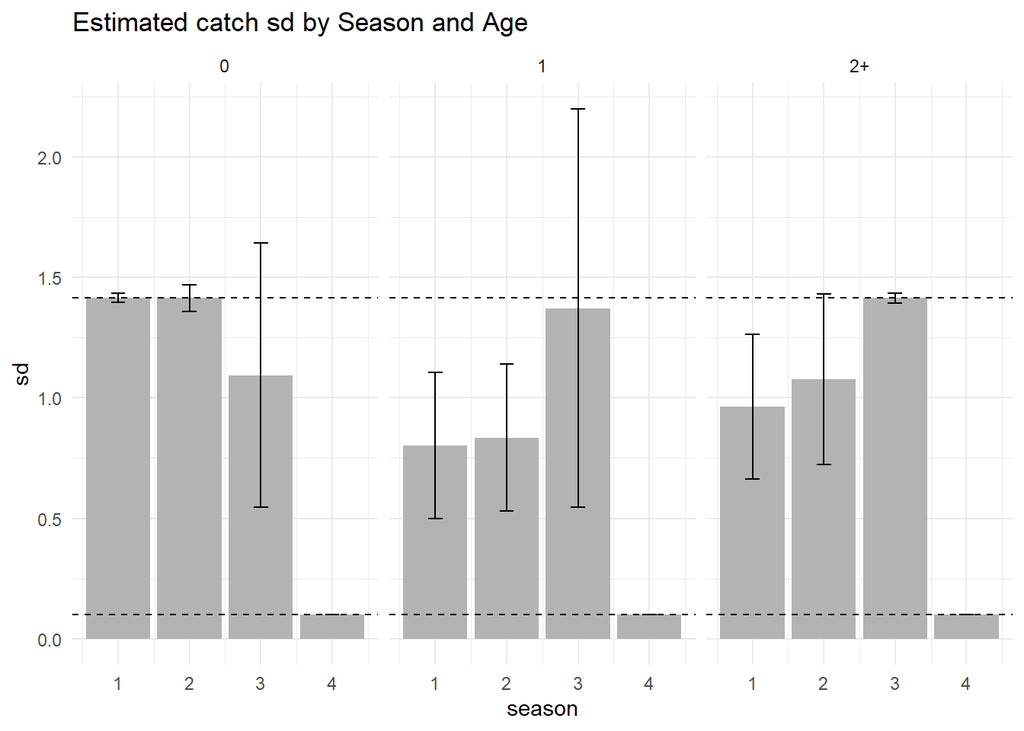

Figure 1: Standard deviation of catches in the current assessment model

```r
print(p1)
```

### Recruitment settings

Since one of current issues with the model is the survey targeting the 0 year olds in Q1, as well as the power parameter associated with that survey, some changes can be made to make these parameters less troublesome. One particular setting that was used during the last benchmark is the sample based variance estimator for the stock-recruitment relationship. This means that the standard deviation of the hockey stick relationship was based on the observed differences from the modeled mean rather than being an observed parameter. Additionally, the likelihood contribution of recruitment was penalized by multiplying the likelihood by 0.1. This way of modeling stock recruitment leads to little relationship between the stock recruitment relationship and the modeled recruitment. However, it is also violating some core assumptions in integrated models, where the estimation model itself is regulating the relative strength between likelihood components.

We therefore propose two changes to settings that leads to marginal changes in the estimated quantities of spawning biomass:

- Remove the survey power law, as it does not improve the retrospective patterns anyway
- Estimate the standard deviation of the stock recruitment relationship, and therefore
- Remove the manual penalty on the likelihood functions.

The estimates of spawning stock biomass, recruitment, and fishing mortality for the models are shown below. We use the 4 season model, but with the catches assigned to the correct season. All models have some issues with the maximum gradient being above an acceptable level with 4 seasons included. This issue relates to the catch SDs estimated.

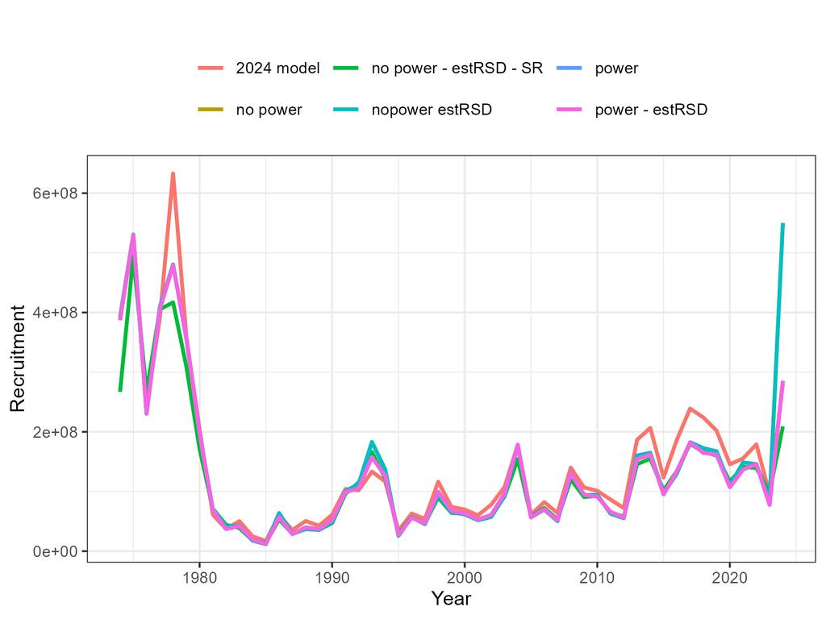

Figure 2: Comparison of models for 0 group settings

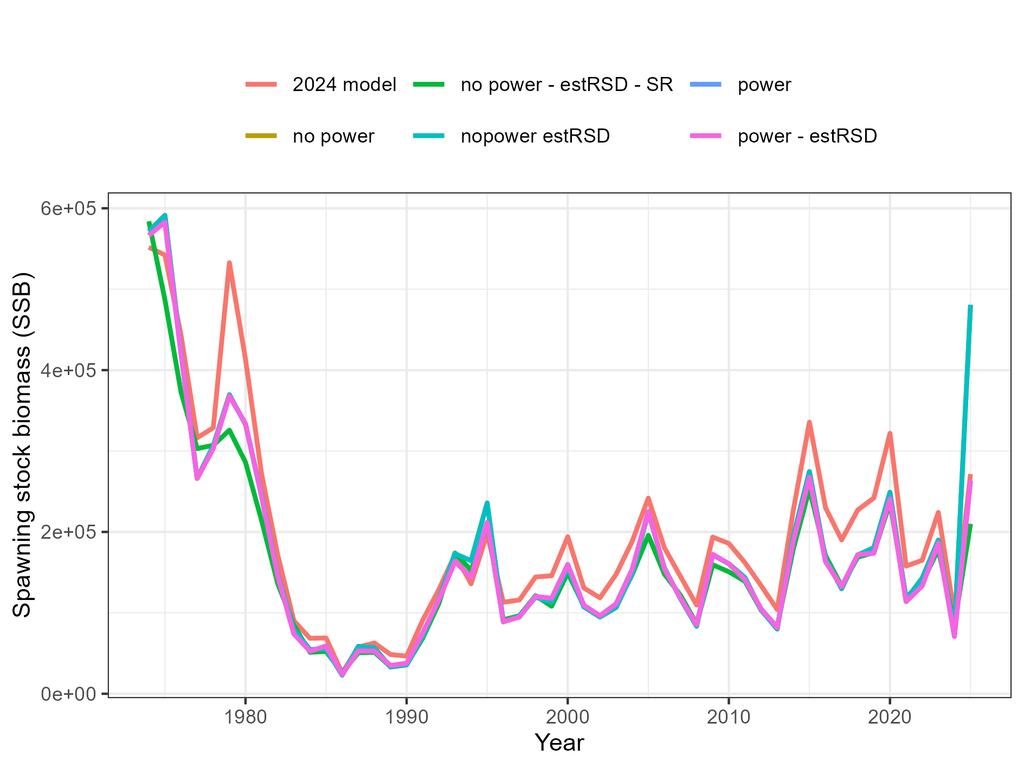

Figure 3: Comparison of models for 0 group settings

## Variable number of seasons in the models

For this benchmark we have decided to start from scratch with the assessment, and not move any catches from one season to the other. To mitigate some of the issues with catch variance, we are here comparing an annual model, a two season model, and the traditional four season model, but without the catches moved between seasons. From the above analysis we went with the no power law, estimate recruitment variation and let the model itself scale the stock recruitment relationship. The choice primarily affects the last year of recruitment. We then reduce the number of seasons to 1, 2, and compare it with the current four seasons to avoid the high catch variance in season 4. For the reduced number of seasons we have adjusted the seasonality of the surveys to match each other.

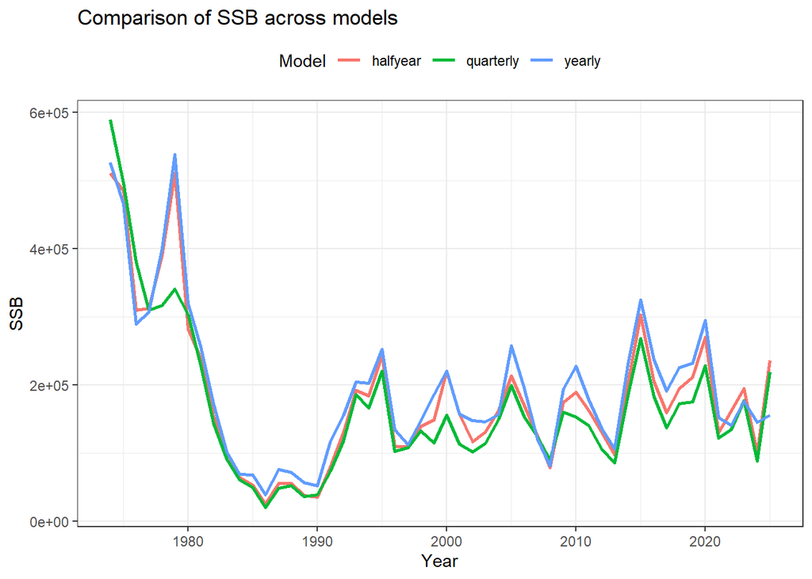

Figure 4: Comparison of SSB across the quarterly, half-yearly, and yearly models.

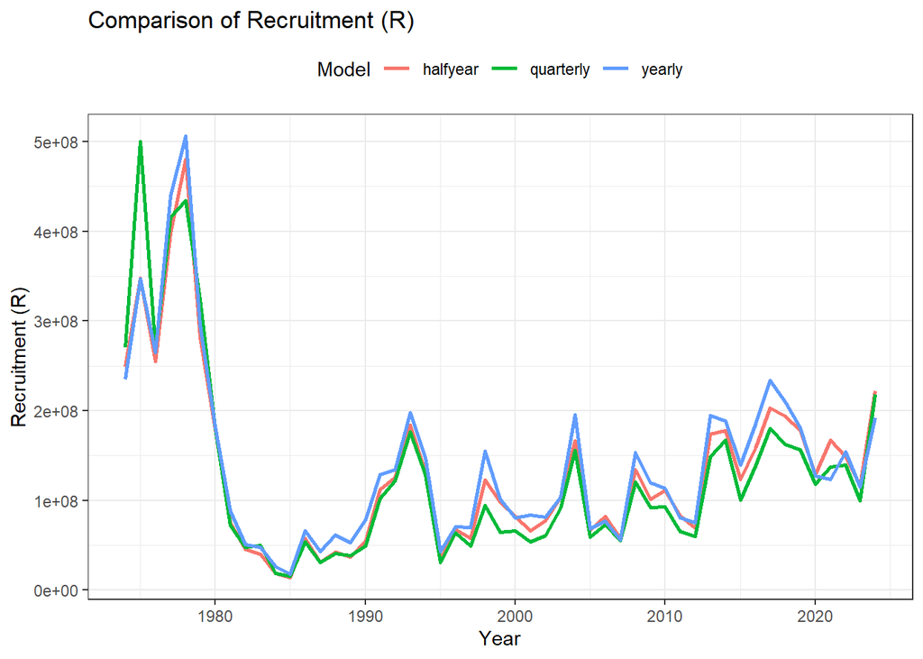

Figure 5: Comparison of recruitment (R) across the three models.

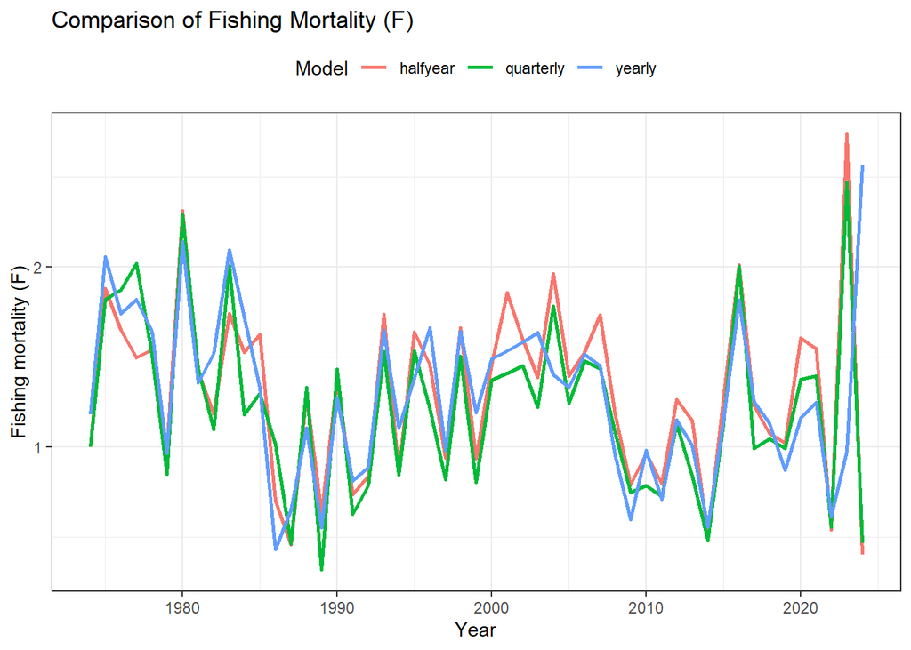

Figure 6: Comparison of fishing mortality (F) across the three models.

All models provide similar output with respect to SSB, R and F (Figure 4, Figure 5, Figure 6), however it seems that a higher number of seasons lead to smaller retrospective patterns (Figure 7). This effect can also be seen in the retrospective patterns of recruitment (Figure 8), and even more in the retrospective patterns of F (Figure 9).

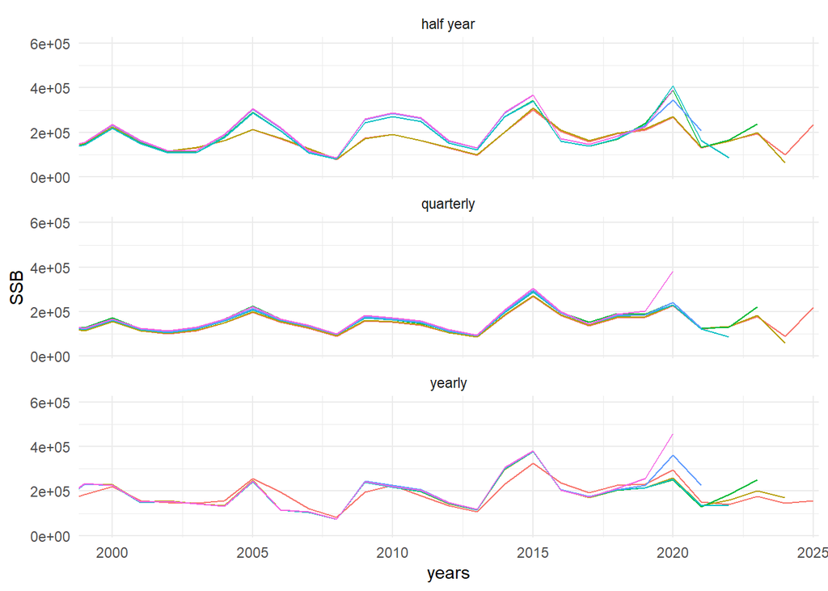

Figure 7: Retrospective patterns of spawning stock biomass from the yearly, half year, and quarterly model

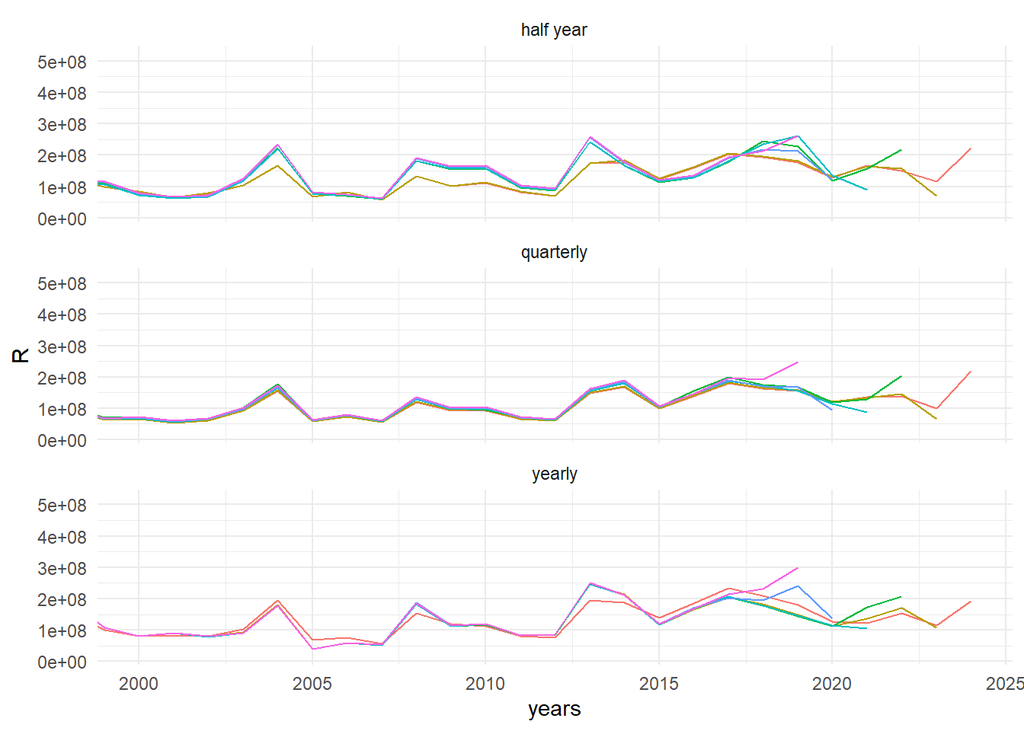

Figure 8: Retrospective patterns of recruitment from the yearly, half year, and quarterly model

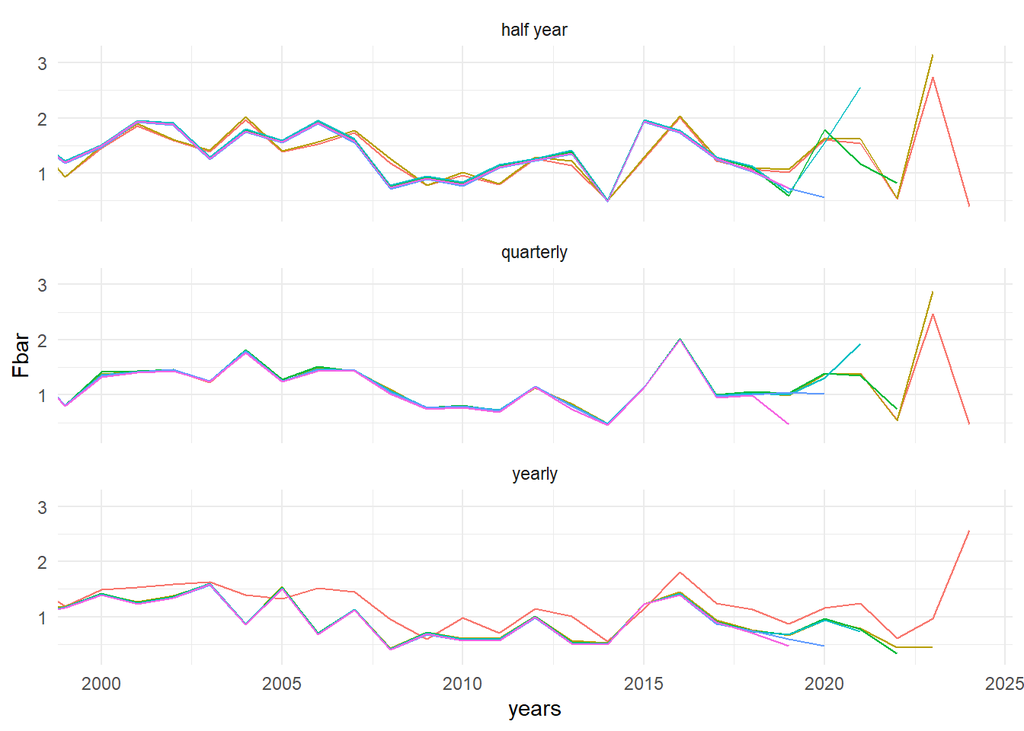

Figure 9: Retrospective patterns of F from the yearly, half year, and quarterly model

The annual model has some fairly strong negative catch residuals, for ages 1-3, as well as autocorrelated patterns in the HERAS survey (Figure 10).

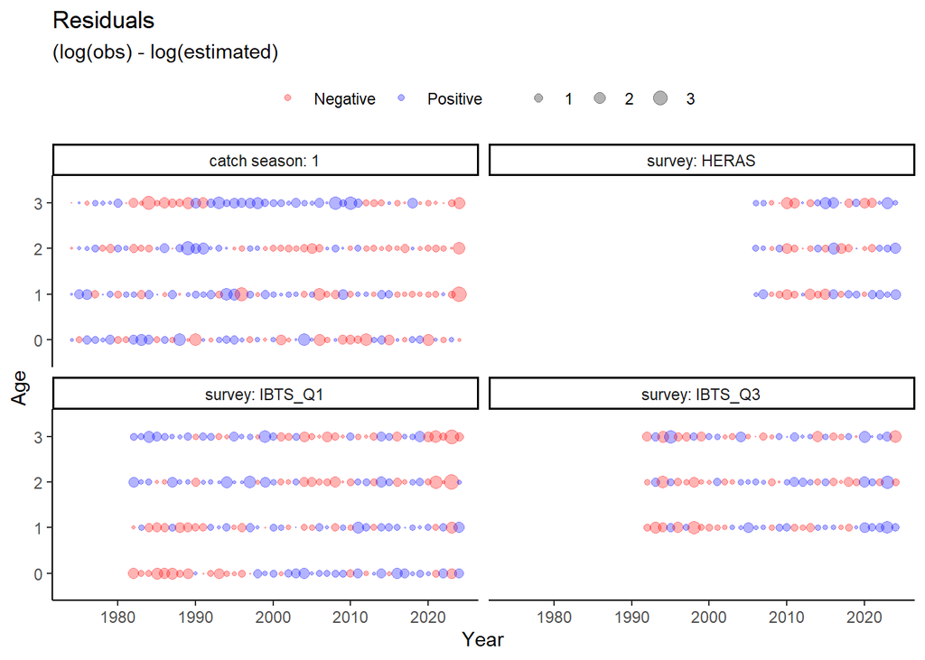

Figure 10: Bubble plot of yearly residuals scaled by sd

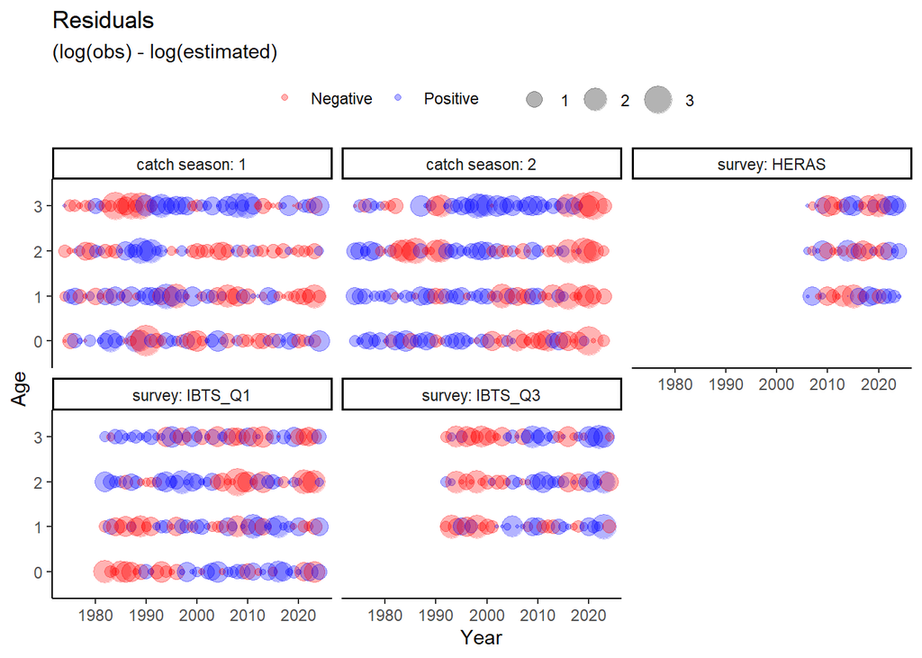

Figure 11: Bubble plot of half year residuals scaled by sd

From the half-year model we see some of the same residual patterns, but that they are concentrated in season 2, where the amount of catches taken are quite low. There are still some issues with age 1 catches in season 1 (Figure 11).

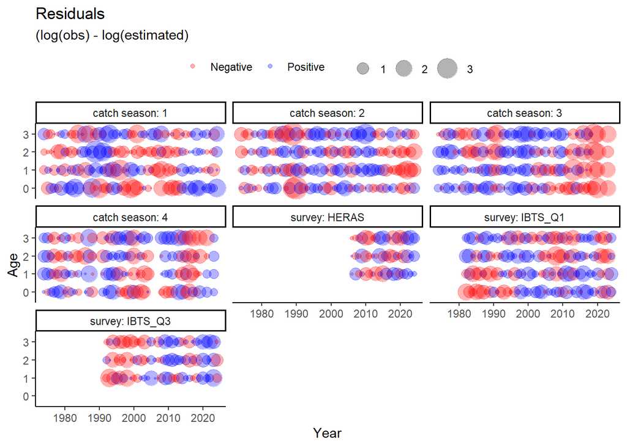

Figure 12: Bubble plot of quarter year residuals scaled by sd

From the four quarter season it is evident that the main problems are occuring in season three in recent years. Likely because there is not much fishing left in that quarter (Figure 12).

## Compare the impact of maturity ogives

We compare three maturity ogives,

1. [0, 0.4, 0.9, 1.0] (DEWG agreed values)
2. [0, 1, 1, 1] (high maturity)
3. [0, 0, 1, 1] (low maturity)

The maturity differences leads to large discrepancy in spawning biomass. This is expected as this number is multiplied by the numbers at age to get the spawning biomass Figure 13.

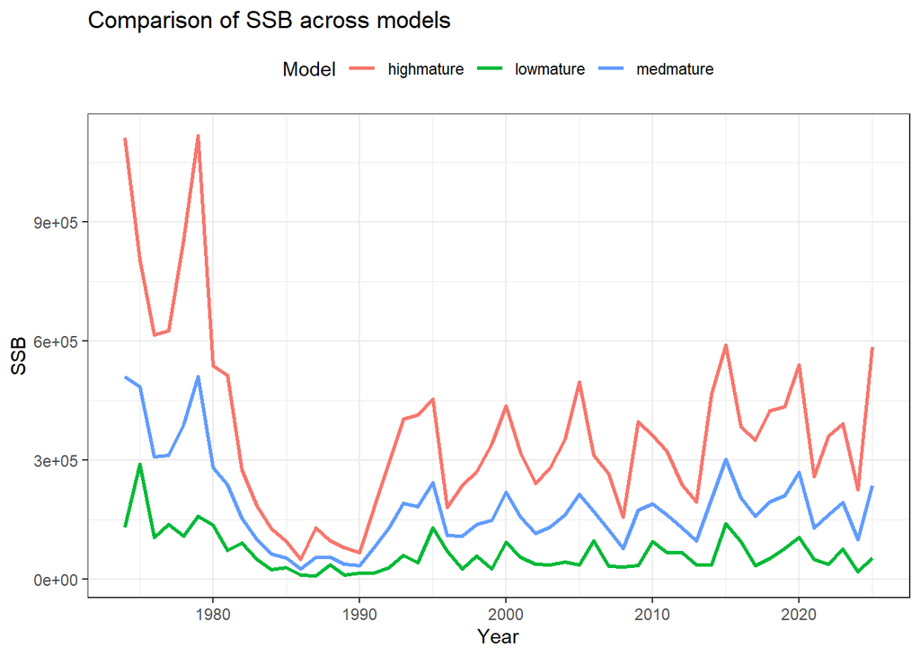

Figure 13: Time series of spawning biomass with three maturity ogives

However, the estimation procedure is only marginally impacted by changing the maturity ogive (Figure 14).

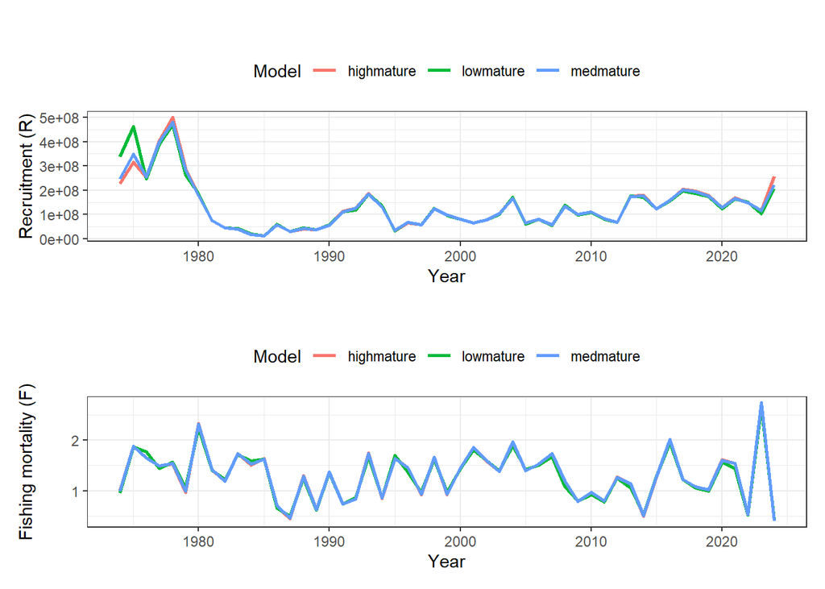

Figure 14: Time series of R and F with three maturity ogives

## Final decisions to take during the meeting

- How do we deal with the distribution of catches among seasons.
- How do we deal with the power law / 0 group
- How many number of seasons are we going to use.

## Adjustments needed before next week

- Fix the poor gradients caused by the catch variance